# Recruiting the Right Person with the Right Skills

PUBADM 505

2026-10-05

## Outline

- Recruiting in public service
- Recruitment: getting started
- Selection
- Federal hiring now
- Case study: Hiring a Sustainable Development Specialist (after the break)

## Recruiting in Public Service

## The Postcard

Chattanooga Police Department, spring 2016. 9,907 postcards to registered voters in the county, each addressed by first name: the same officer’s photo on the front, his signed message on the back. This is one of four versions.

Front

[figure not shown]

Back

The experiment varied only the boxed parts: the tagline and two sentences.

## Four Postcards, One Police Department

Same photo, same officer, same signature. Each version’s tagline and its two sentences:

Serve

“I love being part of the police because I feel I can really make a difference in Chattanooga.”

“If you’re the kind of person who is ready to serve, you’re just the kind of person we’re looking for.”

Challenge

[figure not shown]

“I love being part of the police because you never know what to expect: it’s challenging but rewarding work!”

“If you’re the kind of person who thrives in challenging environments, you’re just the kind of person we’re looking for.”

Impact

[figure not shown]

“I love being part of the police because I feel I can really make a difference in Chattanooga.”

“Just think what it would mean to you and your community if you became a police officer.”

Career

[figure not shown]

“I love being part of the police because I’m constantly developing my skills: this isn’t just a job, it’s a career.”

“If you’re looking for a long-term career, you’re just the kind of person we’re looking for.”

Which postcard brought in the most applicants?

## What Chattanooga Found

Serve

Challenge

[figure not shown]

Impact

[figure not shown]

Career

[figure not shown]

0.2%

Application rate with no postcard

0.6%

Challenge and Career postcards: three times as effective, “without an observable loss in applicant quality”

No different

Serve and Impact postcards, compared with no postcard at all

“For applicants of color and women, the messages focusing on both the challenge and job security were disproportionately impactful.” Before the round, the force was 78% white and 93% male; the city was 56% white and 35% black.

Linos, E. (2018). More than public service: A field experiment on job advertisements and diversity in the police. *JPART*, 28(1), 67–85.

## Who Wants a Government Job?

Linos (2018)

“The number of people interested in government jobs has steadily declined in the past two decades, even among public affairs graduates.”

Fowler and Birdsall (2020)

“Findings suggest that the best and brightest law school graduates are predisposed to employment in the private or nonprofit sectors because they offer the strongest extrinsic or intrinsic incentives.”

Why are you in public service? What would a recruiter need to know about you?

Fowler, L., & Birdsall, C. (2020). Are the best and brightest joining the public service? *Review of Public Personnel Administration*, 40(3), 532–554.

## Effective Recruitment and Selection

- A certain amount of turnover happens in organizations
  - Understanding good versus problematic turnover
- Managers need employees with the right knowledge, skills, and abilities
- Employees want to be valued, developed, and rewarded and they want a place where they fit
- Managers cannot be certain they made a good hire until the person is on the job for a while, but experience helps improve the probability

Person–organization fit: congruence or alignment between an individual and an organization. Their personal values, goals, and ethics align with those of the organization.

## Recruitment: Getting Started

## Key Questions

To start: what are we hiring for?

- Is this a new position or previously filled?
- If it was previously filled, at what level? Should that level remain the same?
- If it is a new position, was a job analysis conducted to ensure the correct qualifications are known?

What else? What are other questions to ask when getting started?

## Who Does the Recruiting and From Where?

Who does the recruiting?

- Centralized
- Decentralized
- Combination
- Outsourced

From where should we hire?

- Internal
- External

What are the benefits of decentralized recruitment? What are the costs?

Peter Principle: individuals in organizations will be promoted up a hierarchy until they reach their level of incompetence. Just because someone is good at one job does not mean they will be good at another.

## Recruitment Strategies

- Strategies range from passive to active
- Think about the position being filled and which strategies will lead to the deepest and most diverse pool of candidates

What are some considerations?

Image of your organizationLabor market/labor poolCurrent composition of current workforceNature of the position

Let’s think about different strategies and how passive or active they are.

## Activity: Recruiting for Public Service in Practice

Think about what kind of information you look for in a job ad. Then review some government and nonprofit job ads and discuss how well they cover that information.

- Federal: search for a position at usajobs.gov. What was your searching process like? What is involved in applying?
- Nonprofit: search for a position at idealist.org. What is involved in the application process?
- Compare: what does each ad tell you about the organization’s values?

In groups, about ten minutes, then share what you found.

## Recruitment Video: Fort Worth Police Department

“WE ARE HIRING!!!” – says Fort Worth Police Department (InsideFWPD, [open on YouTube](https://www.youtube.com/watch?v=-Yy4QXJqFmE))

[interactive chart not shown]

What values are expressed, and what kind of information is provided? Is the video likely to be effective at recruiting job applicants? Why or why not?

## Dot Your I’s

1

Check your application process for unnecessary administrative hurdles and ease of use

2

Ensure compliance with employment laws (e.g. Americans with Disabilities Act)

3

After-action reporting on searches: review metrics and think about where process could be improved

What constitutes successful recruitment?

## Selection

## Selection

Once you have a deep and diverse candidate pool, the time has come to narrow down the pool and make a choice

Screen for minimum requirements

- Be consistent: keep the focus on the standard of job-relatedness

Review your selection procedures

- Need to comply with the Uniform Guidelines on Employee Selection Procedures
- Make sure there is not disparate impact

## Griggs v. Duke Power Co. (1971)

Duke Power required a high school education and satisfactory scores on two professionally prepared aptitude tests for placement in any department but Labor.

Chief Justice Burger, for the Court

“The Act proscribes not only overt discrimination but also practices that are fair in form, but discriminatory in operation. The touchstone is business necessity. If an employment practice which operates to exclude Negroes cannot be shown to be related to job performance, the practice is prohibited.”

Griggs v. Duke Power Co., 401 U.S. 424, 431 (1971). Decided 8–0. The case solidifies the standard of job-relatedness.

## The Uniform Guidelines (1978): The Four-Fifths Rule

29 CFR § 1607.4(D)

“A selection rate for any race, sex, or ethnic group which is less than four-fifths (4/5) (or eighty percent) of the rate for the group with the highest rate will generally be regarded by the Federal enforcement agencies as evidence of adverse impact…”

48 of 80

Group A passes the written test: a 60% selection rate

12 of 40

Group B passes: a 30% selection rate

0.30 ÷ 0.60 = 0.50

Below 0.80: evidence of adverse impact

An illustrative example.

**Where it stands in 2026.** The rule is still in the regulations, and Title VII still prohibits disparate impact (42 U.S.C. § 2000e-2(k)). But the EEOC stopped bringing disparate-impact-only cases in 2025, the Justice Department’s Office of Legal Counsel called the Uniform Guidelines unconstitutional (June 9, 2026), and OPM removed them from federal personnel rules (July 31, 2026).

29 CFR § 1607.4(D) · EO 14281 (Apr. 23, 2025) · OLC, “Constitutionality of Disparate-Impact Liability Under Title VII” (June 9, 2026) · OPM interim final rule (July 31, 2026)

## What Counts as an Employment Test?

Uniform Guidelines, 29 CFR § 1607.16(Q)

Selection procedure: “Any measure, combination of measures, or procedure used as a basis for any employment decision.”

Any mechanism used to screen a potential employee is considered a test and therefore must meet the standards of validity and reliability.

SHRM

“Standardized devices designed to measure skills, intellect, personality or other characteristics, and they yield a score, rating, description or category.”

By the legal definition, is a job interview a test? A resume screen?

## Tests

Different types of employment tests

- Written exams (e.g., civil service exam)
- Performance tests
- Fitness tests

What tests are appropriate for the positions being filled?

- Have you ever taken an employment test?
- Did you think it was fair?

KEY: Must be VALID and RELIABLE. What does this mean?

## Reliability and Validity

Reliability

Selection methods produce consistent results and do not vary significantly based on time, place, or person.

Content validity

Content is representative of performance on the job. A data entry speed and accuracy test, for a data entry job.

Criterion validity

A good predictor of desired future performance. Have incumbent employees take the test to see how well it correlates with their job performance.

Construct validity

Accurately measures concepts deemed important for job performance. A test of leadership skills has to measure those skills.

Reliability is a necessary but not sufficient condition for validity.

## Interviews

Should be structured to make sure candidates are treated equally

Structure

Structured interview protocols improve validity and reduce bias

Panel

A panel of reviewers, when possible, can improve interview effectiveness

Training

Train people on effective interviewing

What are some ways to reduce bias and improve the efficacy of interviews as a selection method?

## Interviews: What To Do and Not To Do

Effective interview questions

- What is your experience with interviews? (as the potential employee or the one doing the hiring)
- What questions are particularly effective?

What not to ask

- Illegal
- Inappropriate

Situational question: the applicant must think about how they would handle a hypothetical scenario. Behavioral question: the applicant describes how they handled a past situation.

## Assessment Centers

Often use a combination of techniques

- Interviews
- Performance tests
- Writing samples

Trade-offs

- Can be very effective but require a significant investment of resources
- Often used for promotion activities (e.g. promotion to a management position)

Do any of you have experience with an assessment center? Can you find examples where these are used in government or nonprofits near you?

## True or False?

Employers are prohibited from asking if an applicant is legally permitted to work in the United States.

False

Pre-employment drug tests are not considered medical examinations under the law.

True

Ban the Box laws prohibit employers from checking the criminal record of new hires.

False

Physical fitness tests are illegal under the Uniform Guidelines on Employee Selection Procedures.

False

## Federal Hiring Now

## Russell Vought, OMB Director

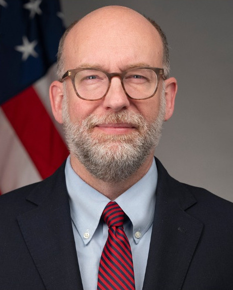

Director, Office of Management and Budget (2020–21; 2025–)

“OMB has the statutory tools of a president to control the bureaucracy. … In the second term, he aims to really use OMB to go after the administrative state.”

“I think the realization that these were bureaucracies that were very hardened, very unaccountable, viewed themselves as very independent of the president, and that needed a macro approach—unified, comprehensive—to be able to ensure that **the president was going to truly be in charge on the basis of democratic representation and not have career bureaucrats running these agencies.** And I think developing that viewpoint out and that realization was something that was different from first to second.”

Bureaucracy and democracy: where does this put the balance?

Russ Vought on the Claremont Institute’s *The American Mind* podcast, as transcribed by RealClearPolitics, Sept. 24, 2026 (emphasis added). Photo: OMB official portrait (2025), public domain.

## Federal Hiring Reform, 2020–2026

Skills-based hiring

Bipartisan, across administrations

2020 · TrumpEO 13932

Judge applicants on job-related skills, not degrees

Dec. 2024 · BidenChance to Compete Act

Technical assessments: position-specific, based on a job analysis, not self-ratings

May 29, 2025 · TrumpMerit Hiring Plan

Self-ratings out for ranking; every hire needs a technical or alternative assessment

July 2026OPM plan to Congress

Self-ratings gone above GS-04; time-to-hire from 101 days (FY 2024) to 80

FY 2028 target100% of positions

So far: 34% of announcements (FY 2026 Q2)

Presidential control

This administration

Jan. 2025 · TrumpEO 14170

Hire for “merit, practical skill, and dedication to our Constitution”

Four essays on GS-05+ postings; political leadership approves hires and may hold an “executive interview”

Nov. 2025Unions sue

*AFGE v. Kupor* (D. Mass.)

Sept. 2026Question 3 stayed, revised

Court stays it Sept. 11; OPM replaces it Sept. 19

The same memo that ends self-ratings also adds the four essays.

Sources: EO 13932 (2020) · P.L. 118-188 (2024) · EO 14170 (2025) · OPM and Domestic Policy Council, Merit Hiring Plan (May 29, 2025) · OPM, Chance to Compete Act implementation plan (July 2026) · OPM bulletin, Sept. 18, 2026

## The Four Essay Questions (2025)

1. The Constitution

“How has your commitment to the Constitution and the founding principles of the United States inspired you to pursue this role within the Federal government? Provide a concrete example from professional, academic, or personal experience.”

2. Efficiency

“In this role, how would you use your skills and experience to improve government efficiency and effectiveness? Provide specific examples where you improved processes, reduced costs, or improved outcomes.”

3. Executive Orders

“How would you help advance the President’s Executive Orders and policy priorities in this role? …”

4. Work ethic

“How has a strong work ethic contributed to your professional, academic or personal achievements? Provide one or two specific examples, and explain how those qualities would enable you to serve effectively in this position.”

200 words per question.

## Question 3, Stayed and Revised

Original (2025)

“How would you help advance the President’s Executive Orders and policy priorities in this role? Identify one or two relevant Executive Orders or policy initiatives that are significant to you, and explain how you would help implement them if hired.”

Revised (Sept. 19, 2026)

“In this role, you will be expected to professionally and efficiently implement executive direction. Provide an example where you implemented leadership direction on a strategy or policy decision that differed from your own recommendation.”

How are employment tests or assessments evaluated to determine whether they are legal and appropriate to use?

## Bringing It Together

- Careful attention to recruitment and selection will lead to better hires
  - The right people with the right skills
  - Good person-organization fit
- Not one best way to do this: need to understand what you need and the factors shaping the decision
  - Job · Temporal and local conditions · Current workforce
- Need to ensure that you follow the law and promote public service values
  - Job-relatedness · Disparate impact

Best measure of effective recruitment and selection is satisfied, productive employees

## Next Week…

**October 12: Compensation and benefits**

Guy & Sowa, Chapter 7

**Case:** Paying the Tucson Police (student-led)

**Due October 12:** final paper proposal, in Canvas by class time. We will workshop proposals in class.

## Case Study: Hiring a Sustainable Development Specialist